BVDOutbreakSize

Appearance

# Sensitivity and comparison analyses

This page continues the main analysis from the one-week-ahead forecast onward: how last week's forecast held up, the outbreak size each data stream implies on its own, how the estimate has evolved across releases, comparisons with McCabe et al. and Chamla et al., and the delay and molecular-clock sensitivity re-fits. It renders from the same fitted chains as the main analysis, loaded through the shared setup, so no model is re-fit here beyond the frozen and (gated) sensitivity re-fits.

**Load packages, data and fitted chains**

julia

```julia
# Shared setup: packages, observations, the fit registry and every model fit
# (loaded from the content-addressed cache). See docs/examples/_setup.jl.
using BVDOutbreakSize
include(joinpath(pkgdir(BVDOutbreakSize), "docs", "examples", "_setup.jl"))
```

```
45
```

## Forecast validation (last week versus now)

How last week's forecast held up against the data since observed, using the frozen re-fit and one-week projection defined in the methods forecast-versus-frozen evaluation. The frozen fit also conditions on the isolation beds, so the projected bed occupancy is scored against the beds held a week later. The bed validation is weak at a one-week-back freeze: the reported occupancy rate starts only on 9 June, so the capacity has no implied-capacity anchor and rides its random walk back to the freeze date, widening the projected bed interval.

**Fit one week back and validate the one-week-ahead forecast**

julia

```julia
# frozen_lastweek is computed in the setup block above.
validation_forecast = forecast_reported(frozen_lastweek.chn;
    horizon = 7,
    obs_cases = frozen_lastweek.o.reported_cases,
    obs_deaths = frozen_lastweek.o.total_deaths,
    obs_confirmed = frozen_lastweek.o.confirmed_cases,
    obs_confirmed_deaths = frozen_lastweek.o.confirmed_deaths);

# The observed beds at the current cut-off (the forecast target), so the
# frozen-fit bed forecast is scored against what the beds actually held.
_obs_beds = isempty(obs.isolation_history.counts) ? missing :
            obs.isolation_history.counts[end]
validation_table = forecast_vs_truth(validation_forecast;
    confirmed = obs.confirmed_cases,
    confirmed_deaths = obs.confirmed_deaths,
    isolation = _obs_beds);
```

**Forecast-versus-observed validation table**

3×9 DataFrame

| Row | Stream String | Observed Float64 | Lower 90% Float64 | Lower 60% Float64 | Lower 30% Float64 | Upper 30% Float64 | Upper 60% Float64 | Upper 90% Float64 | Within 90% PI String |
| --- | --- | --- | --- | --- | --- | --- | --- | --- | --- |
| 1 | DRC confirmed cases | 1561.0 | 1381.0 | 1497.0 | 1586.0 | 1768.0 | 1940.0 | 2324.0 | yes |
| 2 | DRC confirmed deaths | 506.0 | 247.0 | 284.0 | 356.0 | 428.0 | 475.0 | 611.0 | yes |
| 3 | DRC isolation beds | 628.0 | 365.0 | 481.0 | 499.0 | 520.0 | 531.0 | 551.0 | no |

The observation panels histogram the one-week-ahead cumulative forecast made from the frozen fit, with the 90% predictive interval shaded and the count actually observed by the current cut-off drawn as a dashed black rule.

**Forecast-versus-observed plot**

julia

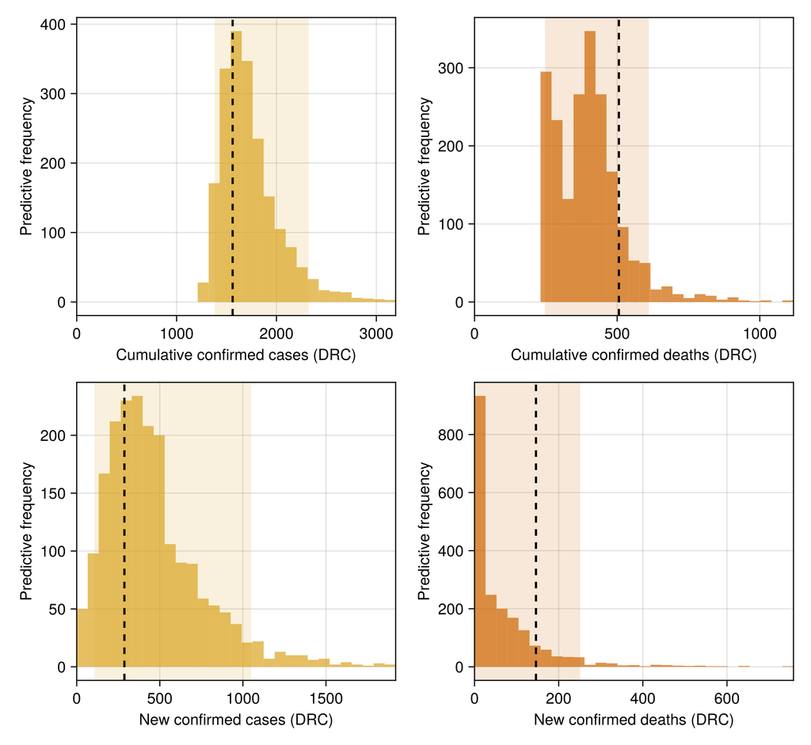

```julia
validation_fig = plot_forecast_vs_truth(validation_forecast;
    confirmed = obs.confirmed_cases,
    confirmed_deaths = obs.confirmed_deaths,
    baseline_confirmed = frozen_lastweek.o.confirmed_cases,
    baseline_confirmed_deaths = frozen_lastweek.o.confirmed_deaths);
```

The bed panel scores last week's projected occupancy against the beds occupied now (the dashed rule).

**Bed forecast-versus-observed plot**

julia

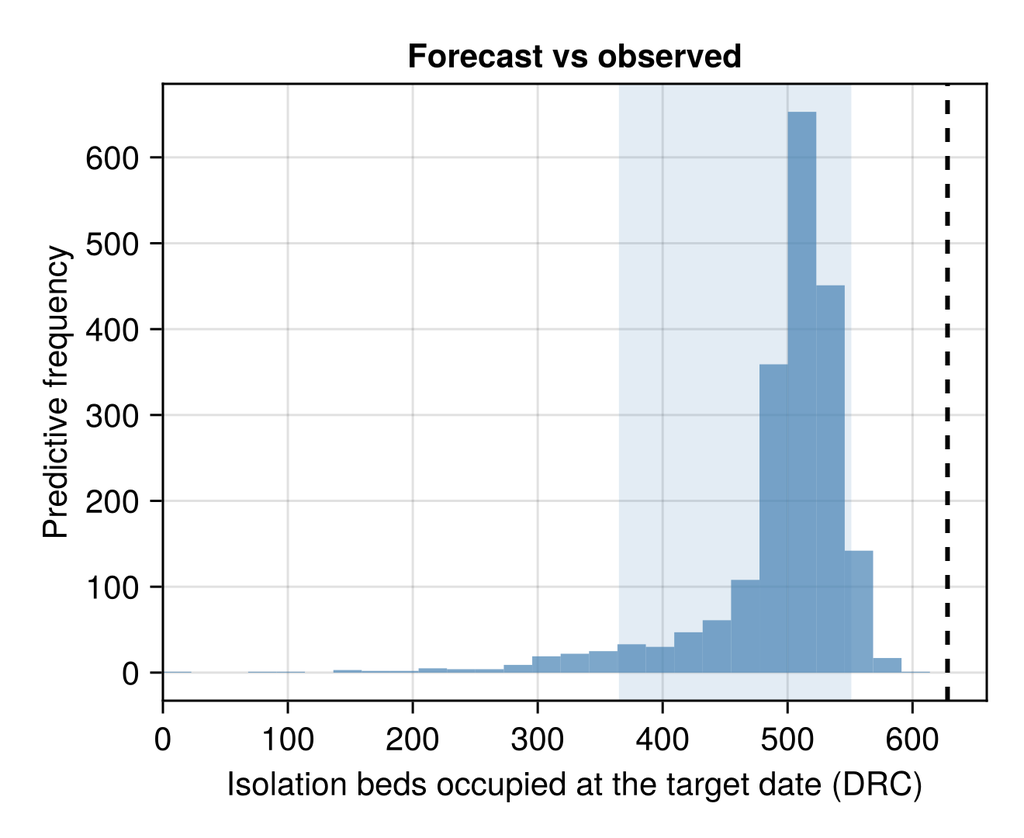

```julia
validation_beds_fig = plot_forecast_beds_vs_truth(validation_forecast;
    isolation = _obs_beds);
```

The latent quantities are not observed, so they are scored distribution against distribution: what the frozen fit forecast for the past week's new infections, onsets and deaths against what the current fit now estimates for the same window.

**Forecast-versus-now latent plot**

julia

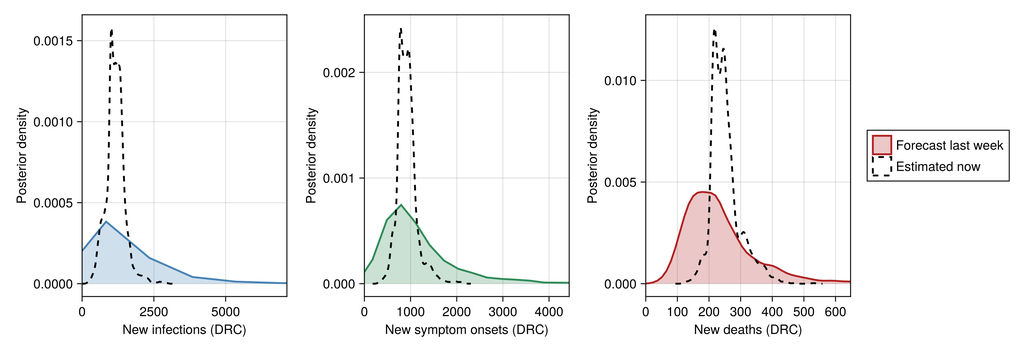

```julia
# Current fit's draws of the new latent counts over the past week, the last
# seven days of each cumulative-trajectory deterministic.
function _now_new(chn, key)
    mat = chn[key]
    trajs = [collect(v) for v in vec(collect(mat))]
    return Float64[t[end] - t[max(1, length(t) - 7)] for t in trajs]
end
now_latent = (;
    infections_new = _now_new(chn_joint, :cumulative_infections),
    onsets_new = _now_new(chn_joint, :cumulative_onsets),
    deaths_latent_new = _now_new(chn_joint, :cumulative_expected_deaths))

validation_latent_fig = plot_forecast_vs_truth_latent(
    validation_forecast; now = now_latent);
```

## Outbreak size estimated by each data stream

Each data stream constrains the latent outbreak size differently. The table below puts the posteriors over the infection count side by side, the single-stream fits and the joint, to show what each stream implies on its own and what the joint adds.

**Per-stream infection-count table**

julia

```julia
streams_C_table = streams_table(
    "exports" => posterior_C_exports,
    "deaths (DRC)" => posterior_C_deaths,
    "cases (DRC)" => posterior_C_cases,
    "confirmed (DRC)" => posterior_C_confirmed,
    "isolation (DRC)" => posterior_C_treatment,
    "joint" => posterior_C_joint);
```

6×7 DataFrame

| Row | Stream String | Lower 90% Float64 | Lower 60% Float64 | Lower 30% Float64 | Upper 30% Float64 | Upper 60% Float64 | Upper 90% Float64 |
| --- | --- | --- | --- | --- | --- | --- | --- |
| 1 | exports | 1293.0 | 2734.0 | 4244.0 | 10805.0 | 22576.0 | 107803.0 |
| 2 | deaths (DRC) | 7919.0 | 10088.0 | 11601.0 | 15455.0 | 18357.0 | 26039.0 |
| 3 | cases (DRC) | 11307.0 | 12824.0 | 14000.0 | 17148.0 | 20089.0 | 30780.0 |
| 4 | confirmed (DRC) | 13530.0 | 16883.0 | 19250.0 | 25410.0 | 30733.0 | 49332.0 |
| 5 | isolation (DRC) | 3387.0 | 4004.0 | 4470.0 | 5600.0 | 6655.0 | 10221.0 |
| 6 | joint | 3922.0 | 4755.0 | 4961.0 | 5571.0 | 5896.0 | 7091.0 |

The first figure shows each single-stream fit's cumulative-infection trajectory projected to the cut-off, with a dotted rule in each stream's colour marking where its data stops and the ribbon beyond it becomes a forward projection.

**Per-stream projected-trajectory plot**

julia

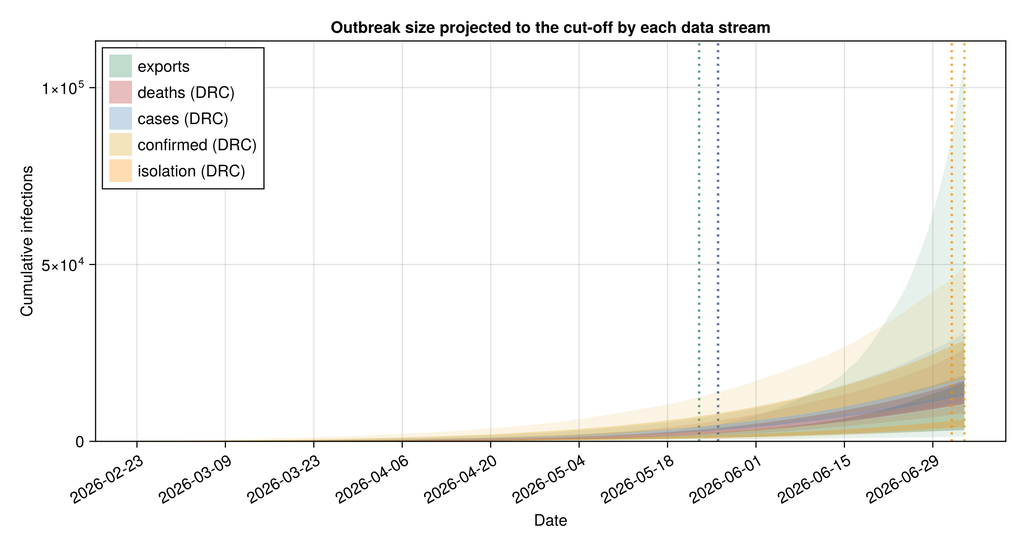

```julia
# Per-draw cumulative-infection trajectory carried by each single-stream
# fit out to the cut-off on day `n`, so streams whose data ends earlier are
# still projected to today.
function _cuminf(chn)
    mat = chn[:cumulative_infections]
    return [collect(v) for v in vec(collect(mat))]
end
# Grid day a stream's data last reports, used for the dotted rule. The
# suspected case and death histories freeze at 26 May; exports and confirmed
# run to the cut-off.
_last_day(days) = isempty(days) ? nothing : maximum(days)

stream_traj_fig = plot_stream_trajectories(
    [
        (; label = "exports", trajs = _cuminf(chn_exports),
            last_day = _last_day(vcat(obs.export_case_days,
                obs.export_death_days)), colour = :seagreen),
        (; label = "deaths (DRC)", trajs = _cuminf(chn_deaths),
            last_day = _last_day(obs.deaths_history.days),
            colour = :firebrick),
        (; label = "cases (DRC)", trajs = _cuminf(chn_cases),
            last_day = _last_day(obs.reported_history.days),
            colour = :steelblue),
        (; label = "confirmed (DRC)", trajs = _cuminf(chn_confirmed),
            last_day = _last_day(obs.confirmed_history.days),
            colour = :goldenrod),
        (; label = "isolation (DRC)", trajs = _cuminf(chn_treatment),
            last_day = _last_day(obs.isolation_history.days),
            colour = :darkorange)];
    n = obs.n, seeding = obs.seeding);
```

The second figure is the posterior density of each fit's cumulative infection count at the cut-off; the x-axis is scaled to a multiple of the joint-fit 90% upper bound so the bulk of the streams stays visible rather than being flattened by the wide, ill-defined confirmed-only tail.

**Cut-off infection-count density plot**

julia

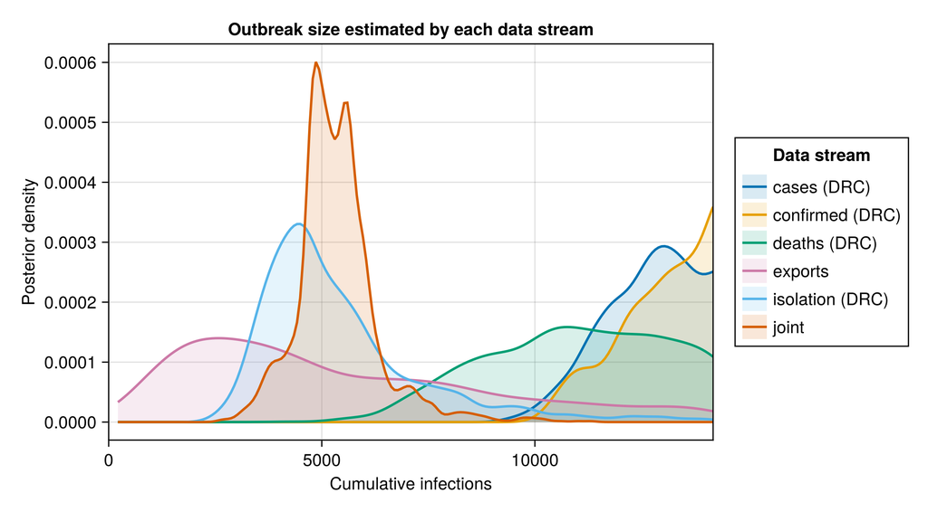

```julia
# Scale the x-axis to twice the joint-fit 90% upper bound, so the joint and
# the streams that track it read clearly while the confirmed-only tail runs
# off the axis rather than dominating it.
density_xmax = 2.0 * quantile(posterior_C_joint, 0.95)

cumulative_density_fig = plot_cumulative_cases(
    "exports" => posterior_C_exports,
    "deaths (DRC)" => posterior_C_deaths,
    "cases (DRC)" => posterior_C_cases,
    "confirmed (DRC)" => posterior_C_confirmed,
    "isolation (DRC)" => posterior_C_treatment,
    "joint" => posterior_C_joint;
    scenarios = [], xmax = density_xmax);
```

The third figure is the reproduction number each stream implies on its own, one panel per stream with the joint fit overlaid in grey as the reference.

**Per-stream implied-Rt plot**

julia

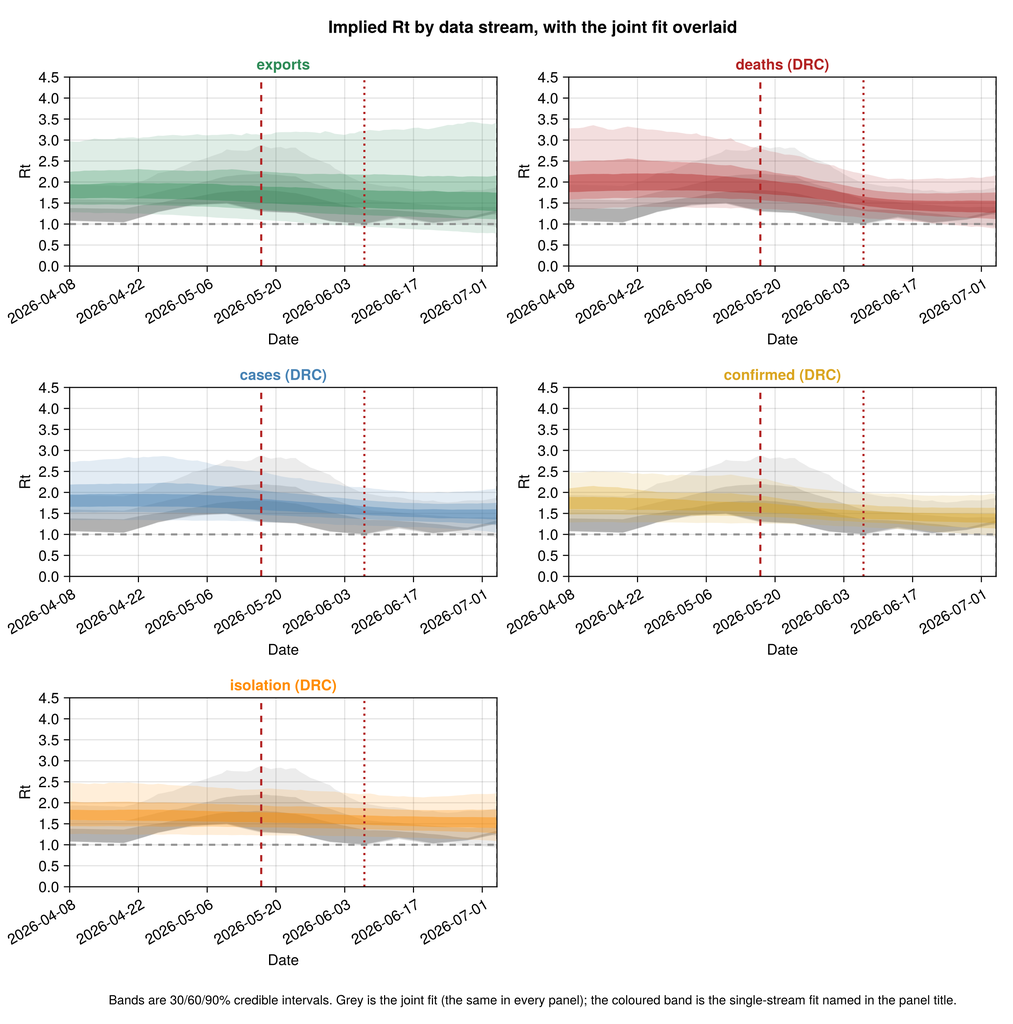

```julia
# The per-stream fits walk Rt from day 1 (the default `rt_start`), while the
# joint walks from `RT_WALK_LEAD` days before the first situation report; the
# shared `display_start` is the joint renewal start so every stream reads over
# the same established window. `ramp` matches the joint Rt figure.
_rt_walk_start_joint = clamp(_BREAKPOINT - RT_WALK_LEAD, _rt_start_plot, obs.n);
stream_rt_fig = plot_rt_streams(
    [
        (; label = "exports", chn = chn_exports, rt_start = 1,
            rt_walk_start = 1, colour = :seagreen),
        (; label = "deaths (DRC)", chn = chn_deaths, rt_start = 1,
            rt_walk_start = 1, colour = :firebrick),
        (; label = "cases (DRC)", chn = chn_cases, rt_start = 1,
            rt_walk_start = 1, colour = :steelblue),
        (; label = "confirmed (DRC)", chn = chn_confirmed, rt_start = 1,
            rt_walk_start = 1, colour = :goldenrod),
        (; label = "isolation (DRC)", chn = chn_treatment, rt_start = 1,
            rt_walk_start = 1, colour = :darkorange)];
    joint = (; label = "joint", chn = chn_joint, rt_start = _rt_start_plot,
        rt_walk_start = _rt_walk_start_joint),
    n = obs.n, breakpoint = _BREAKPOINT,
    as_of_date = string(obs.cutoff), seeding = obs.seeding,
    display_start = _rt_start_plot, ramp = 21.0);
```

The frozen re-fits below freeze the renewal data to an earlier cut-off and re-fit, so that a change driven by newer data can be distinguished from one driven by a change of method. Each uses the full headline settings (1000 draws across two chains), reusing the frozen-fit helper defined above.

**Freeze the renewal data to a cut-off and re-fit**

julia

```julia
# Frozen re-fits and released_df are prepared in the setup block above.
```

## Estimate evolution across releases

How the outbreak-size estimate moved as the situation reports accrued.

The project publishes a tagged results release at each data cut-off (https://github.com/epiforecasts/BVDOutbreakSize/releases), bundling the posterior draws and input data. The released series, in blue, is the project's published estimate at each release: the closed-form integral model up to v1.3.0, then the renewal model from v1.4.0 on. Each release is its own fit, so it is drawn as a discrete estimate, a median with nested 30/60/90% interval bars, rather than a ribbon. The current model frozen at earlier cut-offs is drawn in red as discrete estimates: at the cut-offs matched to the McCabe et al. reports (20, 23 and 27 May), Chamla et al.'s 8 June confirmed-case calibration date, and one week before the current cut-off. These are the frozen joint fits already computed for the matched-in-time comparison, the Chamla comparison and the forecast validation, reused here, so no extra fits are run. The current-data, current-model estimate is drawn in green as the cumulative-infection trajectory over time, a single fit shown across the period so the latest estimate reads against the earlier ones. Each release date is marked with a dotted vertical rule.

**Released estimates and the current-model frozen re-fits**

julia

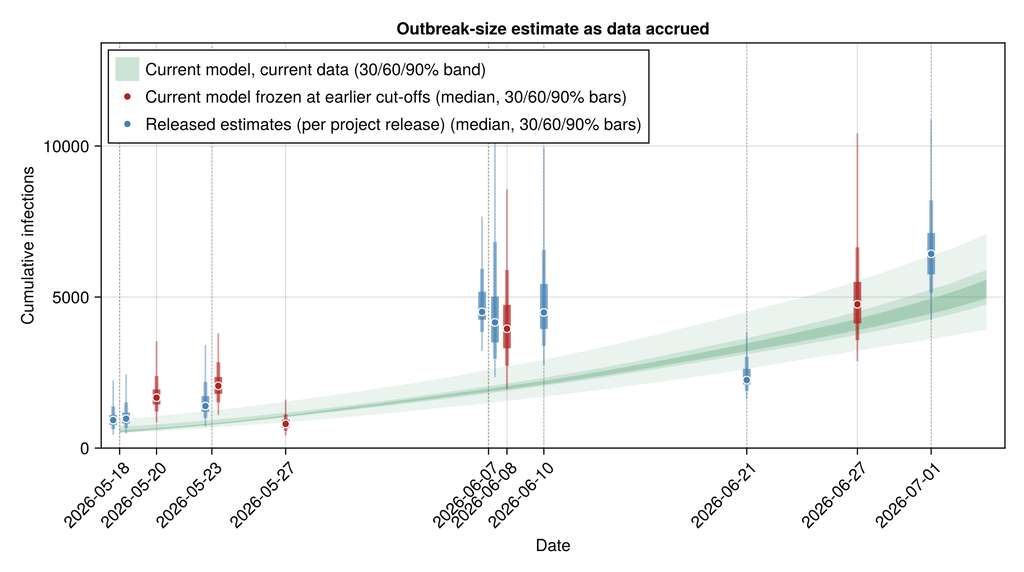

```julia
# Released median and 30/60/90% intervals per release, from
# `data/released_estimates.csv`. Each tuple is
# `(date, median, lo30, hi30, lo60, hi60, lo90, hi90)`.
release_evolution = [(string(r.date), r.median, r.lo30, r.hi30, r.lo60, r.hi60,
                         r.lo90, r.hi90) for r in eachrow(released_df)]

# The current model frozen at earlier cut-offs, each its own discrete
# estimate: the matched-McCabe cut-offs (20, 23, 27 May) already computed
# for the matched-in-time comparison below, the 8 June Chamla
# confirmed-case anchor computed for the Chamla comparison, and the
# one-week-back validation fit (`frozen_lastweek`, at `validation_cutoff`)
# already computed for the forecast validation above. All are reused here so
# the current-model estimate at those earlier cut-offs reads against the
# released overlay, including a recent point one week before the cut-off.
# No extra fits are run. Each tuple carries the median and 30/60/90%
# credible bounds from the frozen `C_T` draws.
function _ci369(xs)
    q(p) = round(Int, quantile(xs, p))
    (q(0.5), q(0.35), q(0.65), q(0.20), q(0.80), q(0.05), q(0.95))
end
frozen_by_cutoff[validation_cutoff] = frozen_lastweek
frozen_matched = [(c, _ci369(frozen_C(c))...)
                  for c in sort(union(frozen_cutoffs,
    [validation_cutoff, default_chamla_cutoff()]))]

# The current-data, current-model estimate as the cumulative-infection
# trajectory over the day grid (one calendar date per grid day, day 1 is
# the seeding date), summarised by per-day 30/60/90% credible bounds. This
# is the same latent quantity the cumulative-trajectory figure shows, so
# the current estimate rises over time on the release-date axis instead of
# sitting flat. Drawn against calendar dates, it lines up with the
# release and frozen points.
infection_trajectory = let
    mat = chn_joint[:cumulative_infections]
    trajs = [collect(v) for v in vec(collect(mat))]
    # Only over the comparison window — from the earliest release date to the
    # cut-off — not back to the seeding date.
    start_day = obs.n - value(obs.cutoff - Date(release_evolution[1][1]))
    days = max(start_day, 1):obs.n
    dates = [obs.seeding + Day(d - 1) for d in days]
    q(d, p) = quantile(Float64[t[d] for t in trajs], p)
    (dates,
        [q(d, 0.35) for d in days], [q(d, 0.65) for d in days],
        [q(d, 0.20) for d in days], [q(d, 0.80) for d in days],
        [q(d, 0.05) for d in days], [q(d, 0.95) for d in days])
end

evolution_fig = plot_estimate_evolution(release_evolution;
    renewal = frozen_matched,
    renewal_label = "Current model frozen at earlier cut-offs",
    trajectory = infection_trajectory,
    title = "Outbreak-size estimate as data accrued");
```

## Comparison with McCabe et al.

Our model is a discrete-time renewal model with a time-varying reproduction number and every data stream fitted jointly. McCabe et al. published their estimates as scenarios at fixed situation-report cut-offs, each scenario carrying a 95% confidence interval. We show all three, the 18 May report, the 20 May update and the 27 May Lancet publication, as one panel each, with their intervals kept. Within a panel each method and scenario family is a single line, carrying its sweep over the nuisance assumptions: the case-fatality ratio, the geographic window and the doubling time. The geographic-spread scenarios come from exported cases and travel volume. Their back-calculation-from-deaths scenarios differ between the reports, since the 18 May report used 88 reported deaths and the 20 May update 131, with a corrected set of case-fatality ratios. McCabe's scenarios estimate cumulative cases at their report dates, though their report is not fully explicit about whether this is symptomatic cases or all infections. We take the like-for-like quantity to be our cumulative symptom onsets, the symptomatic cases, on the same dates, rather than the latent infections (which include the not-yet-symptomatic) or our current cut-off total. We read our value off the joint fit's cumulative-onset trajectory at the grid day for each report date and show it with its credible interval, the 18 May report against our 18 May value, the 20 May update against our 20 May value, and the 27 May Lancet publication against our 27 May value, so each scenario sits beside our estimate for the date it was made.

**McCabe scenarios with uncertainty against our estimates**

julia

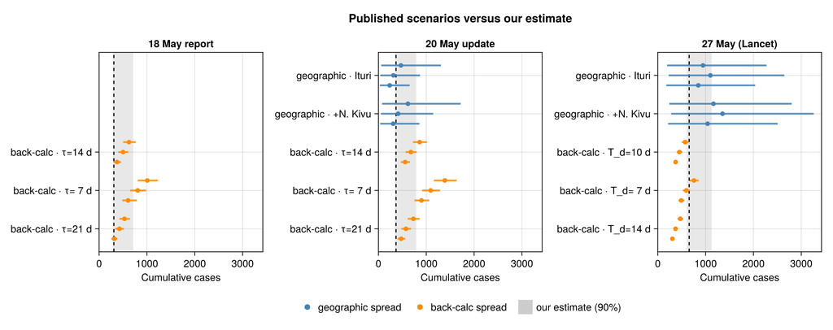

```julia
function _ci90row(xs)
    (round(Int, quantile(xs, 0.5)),
        round(Int, quantile(xs, 0.05)),
        round(Int, quantile(xs, 0.95)))
end

# Our modelled cumulative symptom onsets on a McCabe report date, read off
# the joint fit's per-draw `cumulative_onsets` trajectory. The grid runs to
# the cut-off on day `n`, so the day-index for a date is `n` minus the days
# from that date back to the cut-off (`grid_day("2026-06-07") = n`,
# `"2026-05-20") = n - 18`, `"2026-05-18") = n - 20`).
_onset_trajs = let mat = chn_joint[:cumulative_onsets]
    [collect(v) for v in vec(collect(mat))]
end
# Inverse of `grid_date(day) = obs.cutoff - Day(obs.n - day)`: the day-index
# whose calendar date is `date`, using `value` (imported above) for the
# day count rather than the non-exported `Dates.date2epochdays`.
_grid_day(date) = obs.n - value(obs.cutoff - Date(date))
function _ours_on(date)
    d = _grid_day(date)
    _ci90row(Float64[t[d] for t in _onset_trajs])
end

# Our matched cumulative-onset estimate for each report date, keyed by date so
# it lands beside that vintage's scenarios in its own panel.
mccabe_ours = Dict(
    "2026-05-18" => _ours_on("2026-05-18"),
    "2026-05-20" => _ours_on("2026-05-20"),
    "2026-05-27" => _ours_on("2026-05-27"))

# One panel per report date; within a panel each method-and-family is one row,
# with the case-fatality / window / doubling-time sweep dodged onto that single
# line, so the ~40 scenarios keep their intervals without becoming ~40 rows.
matched_comparison_fig = plot_scenario_comparison(REPORT_SCENARIOS_CI;
    ours = mccabe_ours,
    date_titles = ["2026-05-18" => "18 May report",
        "2026-05-20" => "20 May update",
        "2026-05-27" => "27 May (Lancet)"],
    xlabel = "Cumulative cases");
```

The McCabe scenarios are outbreak-size estimates, the same quantity our renewal model and the released integral model report. Their 95% confidence intervals come from exact negative-binomial counts for the geographic-spread method and a Poisson likelihood profile for the back-calculation from deaths.

**Frozen-fit C_T intervals (kept for the CSV export, not shown)**

julia

```julia
# The estimate-evolution figure above already shows how the size estimate
# shifts as data accrues, so the side-by-side frozen-fit table is no longer
# rendered in the report; it is kept only to populate the published
# `frozen_matched_cutoffs.csv` export.
frozen_streams_table = streams_table(
    "frozen 20 May" => frozen_C("2026-05-20"),
    "frozen 23 May" => frozen_C("2026-05-23"),
    "frozen 27 May" => frozen_C("2026-05-27"),
    "frozen 8 June" => frozen_C(default_chamla_cutoff()),
    "current data" => posterior_C_joint);
```

## Comparison with Chamla et al.

A second group, Chamla et al. (Chamla *et al.*, 2026) at the World Health Organization Regional Office for Africa, published a stochastic compartmental model of the same outbreak on 25 June 2026. Their model is a discrete-time susceptible-exposed-infectious-recovered-dead ensemble, recalibrated by simulation filtering to the laboratory-confirmed case series, anchored on the 598 confirmed cases reported by 8 June, then run forward to project the confirmed-case trajectory under a low, central and high transmissibility scenario.

Their published quantity is the cumulative confirmed-case count, with the reporting fraction held at one, so it does not adjust for the cases that are infected but never laboratory-confirmed. This is a different quantity from the cumulative cases this analysis and McCabe et al. estimate, which include the unconfirmed and unascertained, and it sits below them: it is a floor on the true size rather than an estimate of it. The like-for-like comparison is therefore against our own confirmed-case projection, not against our cumulative infection count.

We compare forward projections rather than refitting to their assumptions. We take our fit frozen at 8 June, the exact date of their confirmed-case calibration anchor, and roll its confirmed-case stream forward to the dates Chamla report with the same machinery as the one-week-ahead forecast. Setting our projection, their projection and the confirmed cases observed since on one timeline shows how each projection has held up against the data.

**Project the 8 June fit forward and assemble the Chamla comparison**

julia

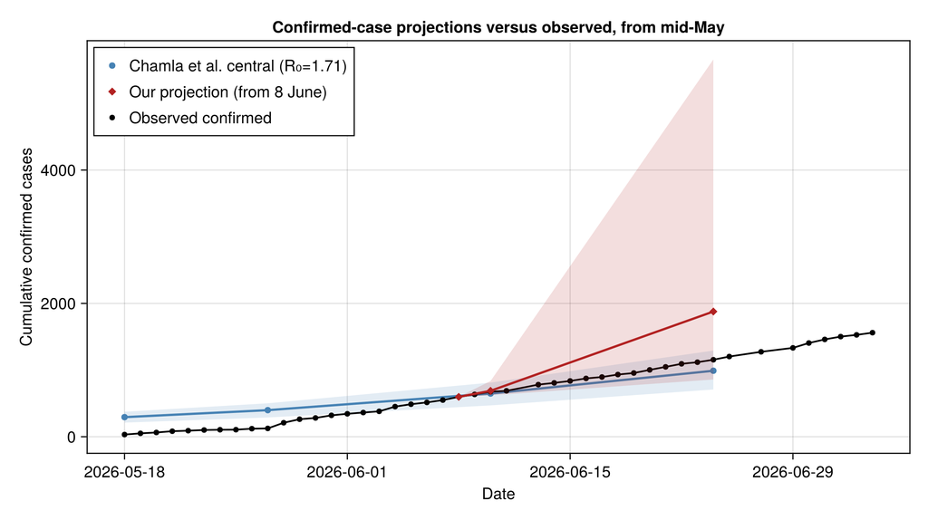

```julia
# The 8 June frozen joint fit matches Chamla's confirmed-case calibration
# anchor exactly and carries the confirmed-case testing history through then,
# so we roll its confirmed-case stream forward with the one-week-ahead forecast
# machinery to the dates Chamla report.
chamla_anchor = frozen_by_cutoff["2026-06-08"]

# Our projected cumulative confirmed cases at a horizon of `h` days past the
# 8 June cut-off: a forward `forecast_reported` run (its reproduction number
# left to keep evolving), summarised as (median, 5%, 95%).
function _our_confirmed_h(h)
    fc = forecast_reported(chamla_anchor.chn;
        horizon = h,
        obs_cases = chamla_anchor.o.reported_cases,
        obs_deaths = chamla_anchor.o.total_deaths,
        obs_confirmed = chamla_anchor.o.confirmed_cases,
        obs_confirmed_deaths = chamla_anchor.o.confirmed_deaths)
    return _ci90row(float.(fc.confirmed_cum))
end

# Our projection at Chamla's forward report dates (10 and 24 June, week 12):
# the anchor day is the fitted confirmed total at 8 June, each later date a
# forward forecast. Reused for the matched-date table and the week-12 figure.
chamla_fan = map(["2026-06-08", "2026-06-10", "2026-06-24"]) do d
    h = value(Date(d) - chamla_anchor.cutoff)
    row = h == 0 ?
          (chamla_anchor.o.confirmed_cases, chamla_anchor.o.confirmed_cases,
        chamla_anchor.o.confirmed_cases) : _our_confirmed_h(h)
    (d, row...)
end
_fan_at(date) =
    let r = first(x for x in chamla_fan if x[1] == date)
        (r[2], r[3], r[4])
    end
ours_10jun = _fan_at("2026-06-10")
ours_24jun = _fan_at("2026-06-24")

# Observed confirmed cases over the comparison window: the daily cumulative
# series read off the chain's grid from 18 May (Chamla's first projected point)
# to the cut-off.
chamla_obs_series = let
    ds = [grid_date(d) for d in obs.confirmed_history.days]
    cs = obs.confirmed_history.counts
    [(string(ds[i]), cs[i]) for i in eachindex(ds) if ds[i] >= Date("2026-05-18")]
end

# Chamla's central confirmed-case projection over the comparison window; their
# later, far-larger horizons are noted in the text rather than plotted so the
# window stays legible.
chamla_central_window = CHAMLA_CONFIRMED_CENTRAL[1:4]

chamla_projection_fig = plot_projection_comparison(;
    external = chamla_central_window,
    ours = chamla_fan,
    observed = chamla_obs_series,
    external_label = "Chamla et al. central (R₀=1.71)",
    ours_label = "Our projection (from 8 June)",
    observed_label = "Observed confirmed",
    title = "Confirmed-case projections versus observed, from mid-May");
```

By 24 June their central scenario projected just under a thousand confirmed cases, and their low and high scenarios ranged from roughly 870 to 1360. The figure below sets that week-12 scenario spread beside our 8 June projection for the same date and the confirmed count observed by the cut-off, so each reads against their three scenarios at a glance.

**Week-12 (24 June) scenario spread against ours and observed**

julia

[figure not shown]

```julia
chamla_w12_rows = vcat(
    [(label, m, lo, hi) for (label, m, lo, hi) in CHAMLA_CONFIRMED_W12],
    [("Our projection (from 8 June)", ours_24jun...)],
    [("Observed by 23 June cut-off", obs.confirmed_cases,
        obs.confirmed_cases, obs.confirmed_cases)])
chamla_w12_groups = vcat(fill("Chamla et al. scenarios", 3),
    ["Our projection"], ["Observed"])

chamla_w12_fig = plot_estimate_comparison(chamla_w12_rows;
    xlabel = "Cumulative confirmed cases by 24 June",
    groups = chamla_w12_groups,
    group_colours = ["Chamla et al. scenarios" => :steelblue,
        "Our projection" => :firebrick,
        "Observed" => :black]);
```

**Matched-date projection numbers (10 and 24 June)**

julia

```julia
chamla_comparison_table = let
    fmt(t) = string(t[1], " (", t[2], "–", t[3], ")")
    central(date) =
        let r = first(x for x in CHAMLA_CONFIRMED_CENTRAL
            if x[1] == date)
            fmt((r[2], r[3], r[4]))
        end
    DataFrame(
        "Date" => ["10 June", "24 June"],
        "Chamla central (90% PI)" => [central("2026-06-10"),
            central("2026-06-24")],
        "Our projection (90% CrI)" => [fmt(ours_10jun), fmt(ours_24jun)],
        "Observed confirmed" => [
            string(freeze_observations("2026-06-10").confirmed_cases),
            string(obs.confirmed_cases) * " (23 June)"])
end;
```

2×4 DataFrame

[output not shown]

Beyond the comparison window their central scenario continues to roughly 8200 confirmed cases by mid-September, with the high scenario far higher; those longer projections are not set against data here. Their confirmed-case projections are a floor on the outbreak size, so they sit below our cumulative infection count, which adds the unconfirmed and unascertained cases on top.

## Reproduction number behind the projection

**Reproduction number as estimated by the 8 June fit**

julia

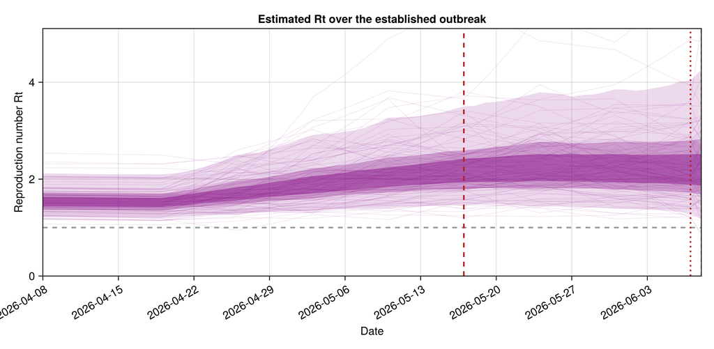

```julia
# Reconstruct the reproduction-number trajectory the 8 June fit estimated,
# mirroring the current-data R_t figure but with the frozen vintage's own grid,
# breakpoint and renewal start.
chamla_rt_obs = chamla_anchor.o
chamla_rt_breakpoint = chamla_rt_obs.n - chamla_rt_obs.who_first_sitrep_days
chamla_rt_start = clamp(
    chamla_rt_obs.n - round(Int, chamla_rt_obs.tmrca_days) + RENEWAL_START_LEAD,
    1, chamla_rt_obs.n)
chamla_rt_fig = plot_rt(chamla_anchor.chn;
    n = chamla_rt_obs.n, breakpoint = chamla_rt_breakpoint,
    rt_start = chamla_rt_start,
    rt_walk_start = clamp(chamla_rt_breakpoint - RT_WALK_LEAD,
        chamla_rt_start, chamla_rt_obs.n),
    as_of_date = string(chamla_rt_obs.cutoff),
    seeding = chamla_rt_obs.seeding, ramp = 21.0);
```

## Delay sensitivity

This sensitivity re-fit runs on main and release docs builds only and is skipped on PR previews to keep the preview builds fast (controlled by the `BVD_RUN_SENSITIVITY` gate in the setup block). When it is skipped the table and figure below are replaced by a short note in place of the re-fit.

The death stream dates the outbreak from how far deaths lag symptom onset, so the assumed onset-to-death delay sets the implied infection count. The baseline uses the hospital-pathway delay from the Isiro 2012 line-list reanalysis (onset to admission then admission to death, implied mean about 12 d). We re-fit the joint model under the community-pathway delay from the same reanalysis, the delay for deaths that occur in the community without a recorded admission, which is shorter (implied mean about 8 d). Both pathways come from the line list, so this varies the actual delay assumption rather than an arbitrary scenario. The re-fit uses the full headline settings (1000 draws across two chains).

The infection count to date shifts with the assumed delay, and the table and overlaid densities below show how far.

**Re-fit the joint under the community-pathway onset-to-death delay**

julia

```julia
# The sensitivity re-fits (community-delay and faster-clock variants) are
# defined in the fit registry (`docs/fits/registry.jl`) and loaded through the cache
# (when enabled) in the setup block above.
posterior_C_community_delay = RUN_SENSITIVITY ?
                              vec(Array(chn_joint_community_delay[:C_T])) : nothing
```

**Delay-sensitivity infection-count table**

julia

```julia
delay_sensitivity_table = RUN_SENSITIVITY ?
                          streams_table("baseline (hospital pathway)" => posterior_C_joint,
    "community pathway" => posterior_C_community_delay) :
                          Markdown.md"_Delay sensitivity runs on main and release builds only; skipped on this build._"
```

*Delay sensitivity runs on main and release builds only; skipped on this build.*

*Delay sensitivity runs on main and release builds only; skipped on this build.*

**Delay-sensitivity infection-count density plot**

julia

```julia
delay_sensitivity_fig = RUN_SENSITIVITY ?
                        plot_cumulative_cases(
    "baseline (hospital pathway)" => posterior_C_joint,
    "community pathway" => posterior_C_community_delay; scenarios = []) :
                        Markdown.md"_Delay sensitivity runs on main and release builds only; skipped on this build._"
```

*Delay sensitivity runs on main and release builds only; skipped on this build.*

*Delay sensitivity runs on main and release builds only; skipped on this build.*

## Clock-rate sensitivity

This sensitivity re-fit runs on main and release docs builds only and is skipped on PR previews to keep the preview builds fast (controlled by the `BVD_RUN_SENSITIVITY` gate in the setup block). When it is skipped the tables and figures below are replaced by a short note in place of the re-fit.

**Re-fit the joint under the faster clock rate**

julia

```julia
# The faster-clock re-fit (and its `tmrca_days` offset) is defined in the fit
# registry (`docs/fits/registry.jl`) and loaded through the cache (when enabled) in the
# setup block above.
posterior_C_fast_clock = RUN_SENSITIVITY ?
                         vec(Array(chn_joint_fast_clock[:C_T])) : nothing
T_baseline_clock = vec(Array(chn_joint[:T]))
T_fast_clock = RUN_SENSITIVITY ? vec(Array(chn_joint_fast_clock[:T])) : nothing
```

The infection count to date under the two clock rates, side by side.

**Clock-rate infection-count table**

julia

```julia
clock_sensitivity_C_table = RUN_SENSITIVITY ?
                            streams_table("baseline clock" => posterior_C_joint,
    "faster clock" => posterior_C_fast_clock) :
                            Markdown.md"_Clock-rate sensitivity runs on main and release builds only; skipped on this build._"
```

*Clock-rate sensitivity runs on main and release builds only; skipped on this build.*

*Clock-rate sensitivity runs on main and release builds only; skipped on this build.*

**Clock-rate infection-count density plot**

julia

```julia
clock_sensitivity_C_fig = RUN_SENSITIVITY ?
                          plot_cumulative_cases("baseline clock" => posterior_C_joint,
    "faster clock" => posterior_C_fast_clock; scenarios = []) :
                          Markdown.md"_Clock-rate sensitivity runs on main and release builds only; skipped on this build._"
```

*Clock-rate sensitivity runs on main and release builds only; skipped on this build.*

*Clock-rate sensitivity runs on main and release builds only; skipped on this build.*

The outbreak age, the number of days from seeding to the cut-off, under the two clock rates. A more recent common ancestor permits a younger outbreak.

**Clock-rate outbreak-age table**

julia

```julia
clock_sensitivity_T_table = RUN_SENSITIVITY ?
                            streams_table("baseline clock" => T_baseline_clock,
    "faster clock" => T_fast_clock; digits = 0) :
                            Markdown.md"_Clock-rate sensitivity runs on main and release builds only; skipped on this build._"
```

*Clock-rate sensitivity runs on main and release builds only; skipped on this build.*

*Clock-rate sensitivity runs on main and release builds only; skipped on this build.*

**Clock-rate outbreak-age density plot**

julia

```julia
clock_sensitivity_T_fig = RUN_SENSITIVITY ?
                          plot_density_overlay("baseline clock" => T_baseline_clock,
    "faster clock" => T_fast_clock;
    xlabel = "Outbreak age (days before cut-off)",
    title = "Posterior outbreak age by clock rate") :
                          Markdown.md"_Clock-rate sensitivity runs on main and release builds only; skipped on this build._"
```

*Clock-rate sensitivity runs on main and release builds only; skipped on this build.*

*Clock-rate sensitivity runs on main and release builds only; skipped on this build.*

## Contact-tracing case-finding sensitivity

These sensitivity re-fits run on main and release docs builds only and are skipped on PR previews to keep the preview builds fast (controlled by the `BVD_RUN_SENSITIVITY` gate in the setup block). When they are skipped the tables and figures below are replaced by a short note in place of the re-fit.

The headline model grounds the suspected-case surveillance in observed contact-tracing effort on both channels case-finding acts through. The daily contact follow-up rate ("taux de suivi des contacts", 7 June-1 July) is modelled as a shared latent rate `q_t`, a logistic random walk over the whole grid fitted to the reported rate, so the anchor is defined before the reported window and projects into forecasts rather than stopping with the data. The non-BVD background scales with it (`exp(β_contact · (q − q̄))`) and the BVD suspected ascertainment carries a reporting-effort multiplier anchored to the same rate plus a random-walk deviation (`exp(β_asc · (q − q̄) + w)`). Both touch the suspected likelihood only, not the shared onsets or `p_drc`, so they carry no ascertainment / outbreak-size confounding [see issue #374].

Two re-fits isolate the two channels: `sens_no_contact` drops the contact grounding entirely (the effort falls back to a free walk and the background to the calendar-time walk), and `sens_no_effort` keeps the contact-scaled background but drops the BVD-ascertainment effort. Each uses the full headline settings (1000 draws across two chains). The current reproduction number and the infection count to date under each are compared with the headline below.

**Load the contact-tracing sensitivity re-fits**

julia

```julia
# The re-fits are defined in the fit registry (`docs/fits/registry.jl`) and
# loaded through the cache (when enabled) in the setup block above.
RTd_headline_contact = vec(Array(chn_joint[:R_T]))
RTd_no_contact = RUN_SENSITIVITY ?
                 vec(Array(chn_joint_no_contact[:R_T])) : nothing
RTd_no_effort = RUN_SENSITIVITY ?
                vec(Array(chn_joint_no_effort[:R_T])) : nothing
posterior_C_no_contact = RUN_SENSITIVITY ?
                         vec(Array(chn_joint_no_contact[:C_T])) : nothing
posterior_C_no_effort = RUN_SENSITIVITY ?
                        vec(Array(chn_joint_no_effort[:C_T])) : nothing
```

**Case-finding reproduction-number table**

julia

```julia
contact_rt_table = RUN_SENSITIVITY ?
                   streams_table(
    "headline (contact-grounded)" => RTd_headline_contact,
    "without contact grounding" => RTd_no_contact,
    "without ascertainment effort" => RTd_no_effort) :
                   Markdown.md"_Contact-tracing sensitivity runs on main and release builds only; skipped on this build._"
```

*Contact-tracing sensitivity runs on main and release builds only; skipped on this build.*

*Contact-tracing sensitivity runs on main and release builds only; skipped on this build.*

**Case-finding reproduction-number density plot**

julia

```julia
contact_rt_fig = RUN_SENSITIVITY ?
                 plot_density_overlay(
    "headline (contact-grounded)" => RTd_headline_contact,
    "without contact grounding" => RTd_no_contact,
    "without ascertainment effort" => RTd_no_effort;
    xlabel = "Current reproduction number R_T",
    title = "Posterior R_T under the contact-tracing case-finding channels") :
                 Markdown.md"_Contact-tracing sensitivity runs on main and release builds only; skipped on this build._"
```

*Contact-tracing sensitivity runs on main and release builds only; skipped on this build.*

*Contact-tracing sensitivity runs on main and release builds only; skipped on this build.*

**Case-finding infection-count table**

julia

```julia
contact_C_table = RUN_SENSITIVITY ?
                  streams_table(
    "headline (contact-grounded)" => posterior_C_joint,
    "without contact grounding" => posterior_C_no_contact,
    "without ascertainment effort" => posterior_C_no_effort) :
                  Markdown.md"_Contact-tracing sensitivity runs on main and release builds only; skipped on this build._"
```

*Contact-tracing sensitivity runs on main and release builds only; skipped on this build.*

*Contact-tracing sensitivity runs on main and release builds only; skipped on this build.*

**Case-finding infection-count density plot**

julia

```julia
contact_C_fig = RUN_SENSITIVITY ?
                plot_cumulative_cases(
    "headline (contact-grounded)" => posterior_C_joint,
    "without contact grounding" => posterior_C_no_contact,
    "without ascertainment effort" => posterior_C_no_effort; scenarios = []) :
                Markdown.md"_Contact-tracing sensitivity runs on main and release builds only; skipped on this build._"
```

*Contact-tracing sensitivity runs on main and release builds only; skipped on this build.*

*Contact-tracing sensitivity runs on main and release builds only; skipped on this build.*

## Saving sensitivity results

The stream-comparison and frozen-fit tables and the per-stream reproduction number figure are written to the shared `output/` directory (the main analysis writes the rest), so the combined release and summary dashboard pick up both pages' outputs.

**Write sensitivity outputs**

julia

```julia
output_dir = get(ENV, "BVD_OUTPUT_DIR",
    joinpath(pkgdir(BVDOutbreakSize), "output"))
mkpath(output_dir)
CSV.write(joinpath(output_dir, "cumulative_cases_by_stream.csv"),
    streams_C_table)
CSV.write(joinpath(output_dir, "frozen_matched_cutoffs.csv"),
    frozen_streams_table)

# The per-stream reproduction-number figure for the summary dashboard; the
# main analysis writes the other three dashboard figures.
dashboard_dir = joinpath(
    pkgdir(BVDOutbreakSize), "docs", "src", "summary_assets")
mkpath(dashboard_dir)
CairoMakie.save(joinpath(dashboard_dir, "rt_streams.png"), stream_rt_fig)
```